# Maladaptive plastic responses of flowering time to geothermal heating (Cerastium 2)

##### Based on 12-h (day) values

Using only daily values of temperature (after 8 am and before or equal to 8 pm).

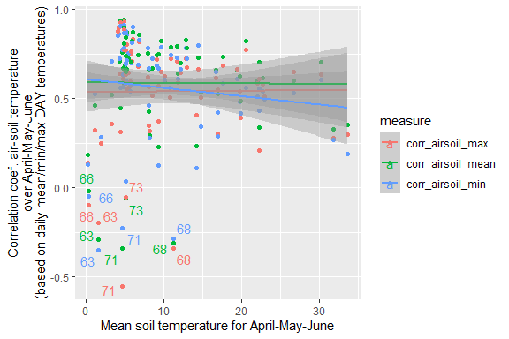

Linear models testing the effect of soil temperature on correlations between soil and air temperature:

| measure | term | estimate | std.error | statistic | p.value |
| --- | --- | --- | --- | --- | --- |
| corr_airsoil_max | (Intercept) | 0.5368293 | 0.0557102 | 9.6360999 | 0.0000000 |
| corr_airsoil_max | meansoiltemp | 0.0002100 | 0.0043195 | 0.0486128 | 0.9613644 |
| corr_airsoil_mean | (Intercept) | 0.5909129 | 0.0561507 | 10.5236931 | 0.0000000 |
| corr_airsoil_mean | meansoiltemp | -0.0004269 | 0.0043536 | -0.0980494 | 0.9221693 |
| corr_airsoil_min | (Intercept) | 0.6083944 | 0.0548987 | 11.0821241 | 0.0000000 |
| corr_airsoil_min | meansoiltemp | -0.0048871 | 0.0042566 | -1.1481222 | 0.2547718 |

Non-significant in all cases.

Linear models testing the effect of soil temperature on correlations between soil and air temperature, removing pairs with negative correlations (5-6 pairs):

| measure | term | estimate | std.error | statistic | p.value |
| --- | --- | --- | --- | --- | --- |
| corr_airsoil_max | (Intercept) | 0.6568292 | 0.0368735 | 17.813044 | 0.0000000 |
| corr_airsoil_max | meansoiltemp | -0.0055417 | 0.0027795 | -1.993793 | 0.0503097 |
| corr_airsoil_mean | (Intercept) | 0.7124420 | 0.0377785 | 18.858386 | 0.0000000 |
| corr_airsoil_mean | meansoiltemp | -0.0062753 | 0.0028477 | -2.203630 | 0.0310445 |
| corr_airsoil_min | (Intercept) | 0.7085154 | 0.0404277 | 17.525472 | 0.0000000 |
| corr_airsoil_min | meansoiltemp | -0.0098199 | 0.0030664 | -3.202460 | 0.0020856 |

All but max are significant.

And the graph:

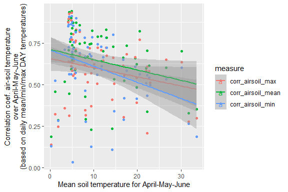

##### Based on positive values

Using only positive values of temperature (>0).

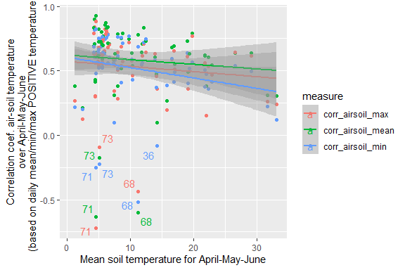

Linear models testing the effect of soil temperature on correlations between soil and air temperature:

| measure | term | estimate | std.error | statistic | p.value |
| --- | --- | --- | --- | --- | --- |
| corr_airsoil_max | (Intercept) | 0.5722864 | 0.0568255 | 10.0709394 | 0.0000000 |
| corr_airsoil_max | meansoiltemp | -0.0039756 | 0.0043611 | -0.9115950 | 0.3652024 |
| corr_airsoil_mean | (Intercept) | 0.6207873 | 0.0603391 | 10.2883137 | 0.0000000 |
| corr_airsoil_mean | meansoiltemp | -0.0035835 | 0.0046308 | -0.7738308 | 0.4417129 |
| corr_airsoil_min | (Intercept) | 0.6056288 | 0.0528874 | 11.4512789 | 0.0000000 |
| corr_airsoil_min | meansoiltemp | -0.0080822 | 0.0040589 | -1.9912301 | 0.0504750 |

Non-significant in all cases.

Linear models testing the effect of soil temperature on correlations between soil and air temperature, removing pairs with negative correlations:

| measure | term | estimate | std.error | statistic | p.value |
| --- | --- | --- | --- | --- | --- |
| corr_airsoil_max | (Intercept) | 0.6487076 | 0.0359797 | 18.029844 | 0.0000000 |
| corr_airsoil_max | meansoiltemp | -0.0070385 | 0.0027214 | -2.586353 | 0.0119480 |
| corr_airsoil_mean | (Intercept) | 0.7033320 | 0.0362586 | 19.397672 | 0.0000000 |
| corr_airsoil_mean | meansoiltemp | -0.0067764 | 0.0027425 | -2.470886 | 0.0161089 |
| corr_airsoil_min | (Intercept) | 0.6757173 | 0.0320621 | 21.075270 | 0.0000000 |
| corr_airsoil_min | meansoiltemp | -0.0100510 | 0.0024280 | -4.139708 | 0.0001037 |

All significant!

And the graph:

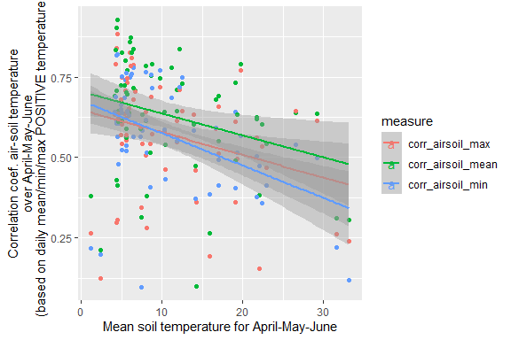

#### Correlations soil-air temperature for May only

##### Based on 24-h values

For each date and logger pair, calculate mean, max and min of air and soil temperature (from, respectively, the above and belowground logger). Then, calculate the correlation coefficient for air and soil temperatures over the month of May. Finally, regress these correlation coefficients on mean soil temperature (from the belowground logger) **for the same period (May)**.

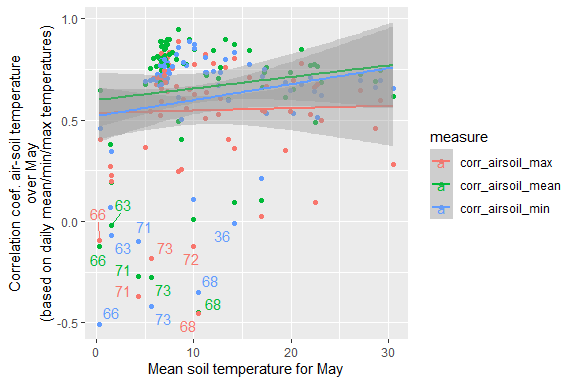

Pairs with negative correlations: 63 (not for max), 66, 68, 71, 72 (not for min), 73.

Linear models testing the effect of soil temperature on correlations between soil and air temperature:

| measure | term | estimate | std.error | statistic | p.value |
| --- | --- | --- | --- | --- | --- |
| corr_airsoil_max | (Intercept) | 0.5339495 | 0.0643113 | 8.3025835 | 0.0000000 |
| corr_airsoil_max | meansoiltemp | 0.0011776 | 0.0048546 | 0.2425635 | 0.8090429 |
| corr_airsoil_mean | (Intercept) | 0.5984971 | 0.0681018 | 8.7882702 | 0.0000000 |
| corr_airsoil_mean | meansoiltemp | 0.0056804 | 0.0051408 | 1.1049748 | 0.2729010 |
| corr_airsoil_min | (Intercept) | 0.5200282 | 0.0656467 | 7.9216145 | 0.0000000 |
| corr_airsoil_min | meansoiltemp | 0.0078510 | 0.0049554 | 1.5843210 | 0.1175651 |

Non-significant in all cases.

Linear models testing the effect of soil temperature on correlations between soil and air temperature, removing pairs with negative correlations:

| measure | term | estimate | std.error | statistic | p.value |
| --- | --- | --- | --- | --- | --- |
| corr_airsoil_max | (Intercept) | 0.6609397 | 0.0454706 | 14.5355395 | 0.0000000 |
| corr_airsoil_max | meansoiltemp | -0.0047924 | 0.0033466 | -1.4320039 | 0.1568618 |
| corr_airsoil_mean | (Intercept) | 0.7613055 | 0.0462880 | 16.4471484 | 0.0000000 |
| corr_airsoil_mean | meansoiltemp | -0.0028649 | 0.0033939 | -0.8441434 | 0.4016387 |
| corr_airsoil_min | (Intercept) | 0.6923881 | 0.0370413 | 18.6923258 | 0.0000000 |
| corr_airsoil_min | meansoiltemp | -0.0006942 | 0.0027174 | -0.2554693 | 0.7991673 |

Non-significant in all cases.

##### Based on 12-h (day) values

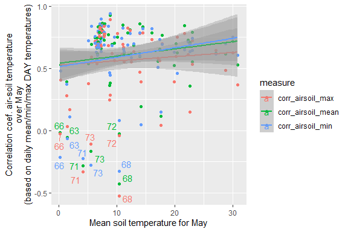

Linear models testing the effect of soil temperature on correlations between soil and air temperature:

| measure | term | estimate | std.error | statistic | p.value |
| --- | --- | --- | --- | --- | --- |
| corr_airsoil_max | (Intercept) | 0.5251973 | 0.0646679 | 8.1214504 | 0.0000000 |
| corr_airsoil_max | meansoiltemp | 0.0033714 | 0.0047894 | 0.7039205 | 0.4837846 |
| corr_airsoil_mean | (Intercept) | 0.5395430 | 0.0639890 | 8.4318116 | 0.0000000 |
| corr_airsoil_mean | meansoiltemp | 0.0057828 | 0.0047392 | 1.2202272 | 0.2264162 |
| corr_airsoil_min | (Intercept) | 0.5120213 | 0.0626557 | 8.1719839 | 0.0000000 |
| corr_airsoil_min | meansoiltemp | 0.0076132 | 0.0046404 | 1.6406225 | 0.1052990 |

Non-significant in all cases.

Linear models testing the effect of soil temperature on correlations between soil and air temperature, removing pairs with negative correlations:

| measure | term | estimate | std.error | statistic | p.value |
| --- | --- | --- | --- | --- | --- |
| corr_airsoil_max | (Intercept) | 0.6481733 | 0.0470410 | 13.7789019 | 0.0000000 |
| corr_airsoil_max | meansoiltemp | -0.0023223 | 0.0033970 | -0.6836405 | 0.4965954 |
| corr_airsoil_mean | (Intercept) | 0.7023117 | 0.0419326 | 16.7485765 | 0.0000000 |
| corr_airsoil_mean | meansoiltemp | -0.0022867 | 0.0030060 | -0.7607030 | 0.4495853 |
| corr_airsoil_min | (Intercept) | 0.6675056 | 0.0435184 | 15.3384720 | 0.0000000 |
| corr_airsoil_min | meansoiltemp | -0.0006324 | 0.0031297 | -0.2020717 | 0.8404823 |

Non-significant in all cases.

##### Based on positive values

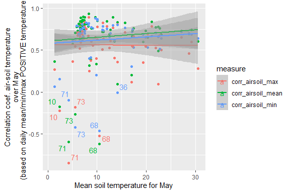

Linear models testing the effect of soil temperature on correlations between soil and air temperature:

| measure | term | estimate | std.error | statistic | p.value |
| --- | --- | --- | --- | --- | --- |
| corr_airsoil_max | (Intercept) | 0.5628730 | 0.0742157 | 7.5842894 | 0.0000000 |
| corr_airsoil_max | meansoiltemp | -0.0003401 | 0.0054842 | -0.0620071 | 0.9507391 |
| corr_airsoil_mean | (Intercept) | 0.6069705 | 0.0750138 | 8.0914467 | 0.0000000 |
| corr_airsoil_mean | meansoiltemp | 0.0044108 | 0.0055432 | 0.7957273 | 0.4289596 |
| corr_airsoil_min | (Intercept) | 0.5762232 | 0.0640076 | 9.0024205 | 0.0000000 |
| corr_airsoil_min | meansoiltemp | 0.0039519 | 0.0047299 | 0.8355228 | 0.4063496 |

Non-significant in all cases.

Linear models testing the effect of soil temperature on correlations between soil and air temperature, removing pairs with negative correlations:

| measure | term | estimate | std.error | statistic | p.value |
| --- | --- | --- | --- | --- | --- |
| corr_airsoil_max | (Intercept) | 0.7228953 | 0.0427540 | 16.9082551 | 0.0000000 |
| corr_airsoil_max | meansoiltemp | -0.0085574 | 0.0030877 | -2.7715005 | 0.0072976 |
| corr_airsoil_mean | (Intercept) | 0.7689999 | 0.0416724 | 18.4534644 | 0.0000000 |
| corr_airsoil_mean | meansoiltemp | -0.0037683 | 0.0030095 | -1.2521306 | 0.2150789 |
| corr_airsoil_min | (Intercept) | 0.6725041 | 0.0389746 | 17.2549451 | 0.0000000 |
| corr_airsoil_min | meansoiltemp | 0.0002265 | 0.0028366 | 0.0798603 | 0.9365976 |

Only significant for max.

And the graph:

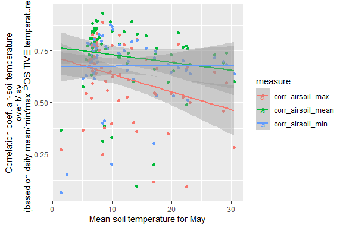

#### Correlations soil-air temperature for June 1-5

##### Based on 24-h values

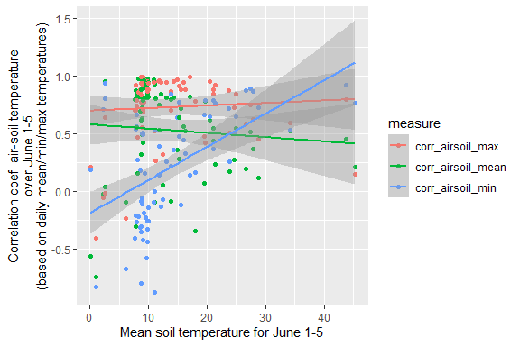

Linear models testing the effect of soil temperature on correlations between soil and air temperature:

| measure | term | estimate | std.error | statistic | p.value |
| --- | --- | --- | --- | --- | --- |
| corr_airsoil_max | (Intercept) | 0.6976189 | 0.0671604 | 10.3873576 | 0.0000000 |
| corr_airsoil_max | meansoiltemp | 0.0022117 | 0.0040996 | 0.5394888 | 0.5912616 |
| corr_airsoil_mean | (Intercept) | 0.5783569 | 0.0884769 | 6.5368106 | 0.0000000 |
| corr_airsoil_mean | meansoiltemp | -0.0036764 | 0.0054008 | -0.6807220 | 0.4982930 |
| corr_airsoil_min | (Intercept) | -0.1903270 | 0.0932753 | -2.0404863 | 0.0450754 |
| corr_airsoil_min | meansoiltemp | 0.0288402 | 0.0056937 | 5.0653113 | 0.0000032 |

Positive significant for min.

### Analyses using pairs with distance < 2

#### Correlations soil-air temperature over the period April-May-June

For each date and logger pair, calculate mean, max and min of air and soil temperature (from, respectively, the above and belowground logger). Then, calculate the correlation coefficient for air and soil temperatures over the period April-May-June. Finally, regress these correlation coefficients on mean soil temperature (from the belowground logger) **for the same period (April-May-June)**.

Using only data till June 5th, included (as most loggers stop on June 6th).

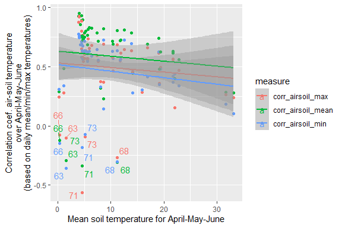

Linear models testing the effect of soil temperature on correlations between soil and air temperature:

| measure | term | estimate | std.error | statistic | p.value |
| --- | --- | --- | --- | --- | --- |
| corr_airsoil_max | (Intercept) | 0.5304296 | 0.0708280 | 7.4889832 | 0.0000000 |
| corr_airsoil_max | meansoiltemp | -0.0039004 | 0.0056562 | -0.6895793 | 0.4937792 |
| corr_airsoil_mean | (Intercept) | 0.6288761 | 0.0788602 | 7.9745647 | 0.0000000 |
| corr_airsoil_mean | meansoiltemp | -0.0041705 | 0.0062976 | -0.6622335 | 0.5109888 |
| corr_airsoil_min | (Intercept) | 0.5156739 | 0.0658971 | 7.8254368 | 0.0000000 |
| corr_airsoil_min | meansoiltemp | -0.0054906 | 0.0052624 | -1.0433740 | 0.3020016 |

Non-significant in all cases.

#### Correlations soil-air temperature for May only

For each date and logger pair, calculate mean, max and min of air and soil temperature (from, respectively, the above and belowground logger). Then, calculate the correlation coefficient for air and soil temperatures over the month of May. Finally, regress these correlation coefficients on mean soil temperature (from the belowground logger) **for the same period (May)**.

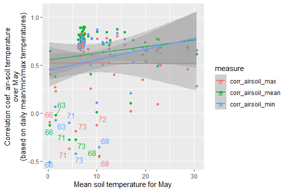

Linear models testing the effect of soil temperature on correlations between soil and air temperature:

| measure | term | estimate | std.error | statistic | p.value |
| --- | --- | --- | --- | --- | --- |
| corr_airsoil_max | (Intercept) | 0.5200013 | 0.0864699 | 6.0136709 | 0.0000002 |
| corr_airsoil_max | meansoiltemp | -0.0001031 | 0.0066566 | -0.0154872 | 0.9877077 |
| corr_airsoil_mean | (Intercept) | 0.5552980 | 0.0904358 | 6.1402436 | 0.0000002 |
| corr_airsoil_mean | meansoiltemp | 0.0068462 | 0.0069619 | 0.9833771 | 0.3303528 |
| corr_airsoil_min | (Intercept) | 0.4477096 | 0.0868626 | 5.1542293 | 0.0000048 |
| corr_airsoil_min | meansoiltemp | 0.0109771 | 0.0066868 | 1.6416126 | 0.1072072 |

Non-significant in all cases.

### Analyses using the 17 pairs where above- and belowground loggers are at the same plant

#### Correlations soil-air temperature over the period April-May-June

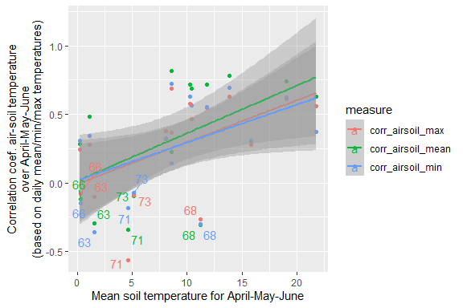

Linear models testing the effect of soil temperature on correlations between soil and air temperature:

| measure | term | estimate | std.error | statistic | p.value |
| --- | --- | --- | --- | --- | --- |
| corr_airsoil_max | (Intercept) | -0.0071435 | 0.1349315 | -0.0529414 | 0.9584772 |
| corr_airsoil_max | meansoiltemp | 0.0304788 | 0.0123633 | 2.4652678 | 0.0262418 |
| corr_airsoil_mean | (Intercept) | 0.0149601 | 0.1556400 | 0.0961197 | 0.9246980 |
| corr_airsoil_mean | meansoiltemp | 0.0347551 | 0.0142607 | 2.4371243 | 0.0277336 |
| corr_airsoil_min | (Intercept) | 0.0177846 | 0.1378222 | 0.1290399 | 0.8990405 |
| corr_airsoil_min | meansoiltemp | 0.0276366 | 0.0126281 | 2.1884936 | 0.0448694 |

Postive relationships are significant in all cases!

#### Correlations soil-air temperature for May only

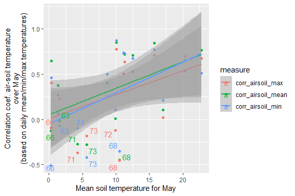

Linear models testing the effect of soil temperature on correlations between soil and air temperature:

| measure | term | estimate | std.error | statistic | p.value |
| --- | --- | --- | --- | --- | --- |
| corr_airsoil_max | (Intercept) | 0.0112482 | 0.1574775 | 0.0714276 | 0.9440011 |
| corr_airsoil_max | meansoiltemp | 0.0263462 | 0.0135001 | 1.9515526 | 0.0699213 |
| corr_airsoil_mean | (Intercept) | 0.0531767 | 0.1768662 | 0.3006604 | 0.7678006 |
| corr_airsoil_mean | meansoiltemp | 0.0291942 | 0.0151623 | 1.9254520 | 0.0733463 |
| corr_airsoil_min | (Intercept) | -0.0480644 | 0.1690743 | -0.2842799 | 0.7800827 |
| corr_airsoil_min | meansoiltemp | 0.0340534 | 0.0144943 | 2.3494321 | 0.0329145 |

Significant only for min, near significance for the others.

# Plot all logger pairs

Make one plot for each logger pair and save all as a pdf in output folder.

After looking at the plots, make a new variable pair_problem: - 0 = no problem - 1 = some problems (remove)

# Q3 Option 2 with logger pairs with no problems

## Analyses using all pairs

### Correlations soil-air temperature over the period April-May-June

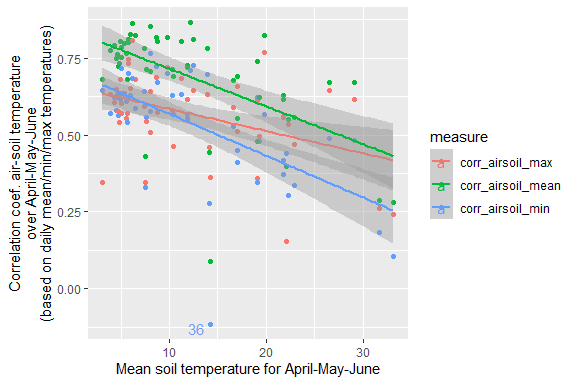

Most of the pairs with negative correlations have disappeared when considering only pairs without problems!

Linear models testing the effect of soil temperature on correlations between soil and air temperature:

| measure | term | estimate | std.error | statistic | p.value |
| --- | --- | --- | --- | --- | --- |
| corr_airsoil_max | (Intercept) | 0.6568341 | 0.0319380 | 20.565933 | 0.0000000 |
| corr_airsoil_max | meansoiltemp | -0.0072069 | 0.0021963 | -3.281420 | 0.0018870 |
| corr_airsoil_mean | (Intercept) | 0.8381035 | 0.0345061 | 24.288540 | 0.0000000 |
| corr_airsoil_mean | meansoiltemp | -0.0122582 | 0.0023729 | -5.165940 | 0.0000042 |
| corr_airsoil_min | (Intercept) | 0.7043187 | 0.0350510 | 20.094122 | 0.0000000 |
| corr_airsoil_min | meansoiltemp | -0.0135863 | 0.0024104 | -5.636639 | 0.0000008 |

All significant.

### Correlations soil-air temperature for May only

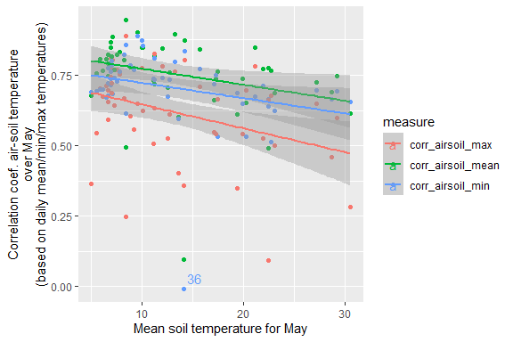

Linear models testing the effect of soil temperature on correlations between soil and air temperature:

| measure | term | estimate | std.error | statistic | p.value |
| --- | --- | --- | --- | --- | --- |
| corr_airsoil_max | (Intercept) | 0.7303409 | 0.0450862 | 16.198769 | 0.0000000 |
| corr_airsoil_max | meansoiltemp | -0.0084423 | 0.0030049 | -2.809453 | 0.0070638 |
| corr_airsoil_mean | (Intercept) | 0.8286498 | 0.0376102 | 22.032561 | 0.0000000 |
| corr_airsoil_mean | meansoiltemp | -0.0056441 | 0.0025067 | -2.251634 | 0.0287701 |
| corr_airsoil_min | (Intercept) | 0.7763669 | 0.0370992 | 20.926806 | 0.0000000 |
| corr_airsoil_min | meansoiltemp | -0.0054087 | 0.0024726 | -2.187446 | 0.0334132 |